# Risk Factor Analysis

## Outcome Variable

**Outcome Variable:** stunted

## Predictor Variables

**Intervention Variable:** vagbrth

**Adjustment Set:**

- arm
- sex
- W_mage
- meducyrs
- feducyrs
- hhwealth_quart
- W_mhtcm
- single
- brthmon
- W_parity
- delta_W_mage
- delta_meducyrs
- delta_feducyrs
- delta_hhwealth_quart
- delta_W_mhtcm
- delta_single
- delta_brthmon
- delta_W_parity

## Stratifying Variables

The analysis was stratified on these variable(s):

- agecat
- studyid
- country

## Data Summary

| agecat | studyid | country | vagbrth | stunted | n_cell | n |
| --- | --- | --- | --- | --- | --- | --- |
| 6 months | ki1000108-CMC-V-BCS-2002 | INDIA | 0 | 0 | 17 | 369 |
| 6 months | ki1000108-CMC-V-BCS-2002 | INDIA | 0 | 1 | 8 | 369 |
| 6 months | ki1000108-CMC-V-BCS-2002 | INDIA | 1 | 0 | 241 | 369 |
| 6 months | ki1000108-CMC-V-BCS-2002 | INDIA | 1 | 1 | 103 | 369 |
| 24 months | ki1000108-CMC-V-BCS-2002 | INDIA | 0 | 0 | 8 | 372 |
| 24 months | ki1000108-CMC-V-BCS-2002 | INDIA | 0 | 1 | 17 | 372 |
| 24 months | ki1000108-CMC-V-BCS-2002 | INDIA | 1 | 0 | 98 | 372 |
| 24 months | ki1000108-CMC-V-BCS-2002 | INDIA | 1 | 1 | 249 | 372 |
| Birth | ki1000108-CMC-V-BCS-2002 | INDIA | 0 | 0 | 9 | 90 |
| Birth | ki1000108-CMC-V-BCS-2002 | INDIA | 0 | 1 | 2 | 90 |
| Birth | ki1000108-CMC-V-BCS-2002 | INDIA | 1 | 0 | 65 | 90 |
| Birth | ki1000108-CMC-V-BCS-2002 | INDIA | 1 | 1 | 14 | 90 |
| 6 months | ki1000108-IRC | INDIA | 0 | 0 | 50 | 407 |
| 6 months | ki1000108-IRC | INDIA | 0 | 1 | 19 | 407 |
| 6 months | ki1000108-IRC | INDIA | 1 | 0 | 257 | 407 |
| 6 months | ki1000108-IRC | INDIA | 1 | 1 | 81 | 407 |
| 24 months | ki1000108-IRC | INDIA | 0 | 0 | 42 | 409 |
| 24 months | ki1000108-IRC | INDIA | 0 | 1 | 27 | 409 |
| 24 months | ki1000108-IRC | INDIA | 1 | 0 | 197 | 409 |
| 24 months | ki1000108-IRC | INDIA | 1 | 1 | 143 | 409 |
| Birth | ki1000108-IRC | INDIA | 0 | 0 | 58 | 388 |
| Birth | ki1000108-IRC | INDIA | 0 | 1 | 10 | 388 |
| Birth | ki1000108-IRC | INDIA | 1 | 0 | 285 | 388 |
| Birth | ki1000108-IRC | INDIA | 1 | 1 | 35 | 388 |
| 6 months | ki1017093b-PROVIDE | BANGLADESH | 0 | 0 | 112 | 583 |
| 6 months | ki1017093b-PROVIDE | BANGLADESH | 0 | 1 | 22 | 583 |
| 6 months | ki1017093b-PROVIDE | BANGLADESH | 1 | 0 | 377 | 583 |
| 6 months | ki1017093b-PROVIDE | BANGLADESH | 1 | 1 | 72 | 583 |
| 24 months | ki1017093b-PROVIDE | BANGLADESH | 0 | 0 | 99 | 577 |
| 24 months | ki1017093b-PROVIDE | BANGLADESH | 0 | 1 | 38 | 577 |

[output cut: 70 more lines]

The following strata were considered:

- agecat: 24 months, studyid: ki1000108-CMC-V-BCS-2002, country: INDIA
- agecat: 24 months, studyid: ki1000108-IRC, country: INDIA
- agecat: 24 months, studyid: ki1017093b-PROVIDE, country: BANGLADESH
- agecat: 24 months, studyid: ki1017093c-NIH-Crypto, country: BANGLADESH
- agecat: 24 months, studyid: ki1066203-TanzaniaChild2, country: TANZANIA, UNITED REPUBLIC OF
- agecat: 24 months, studyid: ki1119695-PROBIT, country: BELARUS
- agecat: 24 months, studyid: ki1126311-ZVITAMBO, country: ZIMBABWE
- agecat: 24 months, studyid: kiGH5241-JiVitA-3, country: BANGLADESH
- agecat: 24 months, studyid: kiGH5241-JiVitA-4, country: BANGLADESH
- agecat: 6 months, studyid: ki1000108-CMC-V-BCS-2002, country: INDIA
- agecat: 6 months, studyid: ki1000108-IRC, country: INDIA
- agecat: 6 months, studyid: ki1017093b-PROVIDE, country: BANGLADESH
- agecat: 6 months, studyid: ki1017093c-NIH-Crypto, country: BANGLADESH
- agecat: 6 months, studyid: ki1066203-TanzaniaChild2, country: TANZANIA, UNITED REPUBLIC OF
- agecat: 6 months, studyid: ki1119695-PROBIT, country: BELARUS
- agecat: 6 months, studyid: ki1126311-ZVITAMBO, country: ZIMBABWE
- agecat: 6 months, studyid: kiGH5241-JiVitA-3, country: BANGLADESH
- agecat: 6 months, studyid: kiGH5241-JiVitA-4, country: BANGLADESH
- agecat: Birth, studyid: ki1000108-CMC-V-BCS-2002, country: INDIA
- agecat: Birth, studyid: ki1000108-IRC, country: INDIA
- agecat: Birth, studyid: ki1017093c-NIH-Crypto, country: BANGLADESH
- agecat: Birth, studyid: ki1119695-PROBIT, country: BELARUS
- agecat: Birth, studyid: ki1126311-ZVITAMBO, country: ZIMBABWE
- agecat: Birth, studyid: kiGH5241-JiVitA-3, country: BANGLADESH
- agecat: Birth, studyid: kiGH5241-JiVitA-4, country: BANGLADESH

### Dropped Strata

Some strata were dropped due to rare outcomes:

- agecat: Birth, studyid: ki1000108-CMC-V-BCS-2002, country: INDIA
- agecat: Birth, studyid: ki1017093c-NIH-Crypto, country: BANGLADESH
- agecat: 24 months, studyid: ki1066203-TanzaniaChild2, country: TANZANIA, UNITED REPUBLIC OF
- agecat: Birth, studyid: ki1119695-PROBIT, country: BELARUS
- agecat: Birth, studyid: kiGH5241-JiVitA-3, country: BANGLADESH
- agecat: Birth, studyid: kiGH5241-JiVitA-4, country: BANGLADESH

## Methods Detail

We’re interested in the causal parameters $E[Y_a]$ for all values of $a \in \mathcal{A}$. These parameters represent the mean outcome if, possibly contrary to fact, we intervened to set all units to have $A=a$. Under the randomization and positivity assumptions, these are identified by the statistical parameters $\psi_a=E_W[E_{Y|A,W}(Y|A=a,W)]$. In addition, we’re interested in the mean of $Y$, $E[Y]$ under no intervention (the observed mean). We will estimate these parameters by using SuperLearner to fit the relevant likelihood factors – $E_{Y|A,W}(Y|A=a,W)$ and $p(A=a|W)$, and then updating our likelihood fit using a joint TMLE.

For unadjusted analyses ($W=\{\}$), initial likelihoods were estimated using Lrnr_glm to estimate the simple $E(Y|A)$ and Lrnr_mean to estimate $p(A)$. For adjusted analyses, a small library containing Lrnr_glmnet, Lrnr_xgboost, and Lrnr_mean was used.

Having estimated these parameters, we will then use the delta method to estimate relative risks and attributable risks relative to a prespecified baseline level of $A$.

# Results Detail

## Results Plots

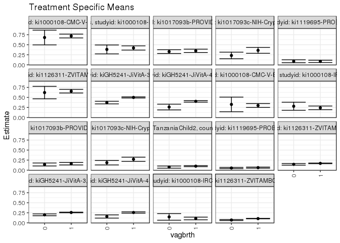

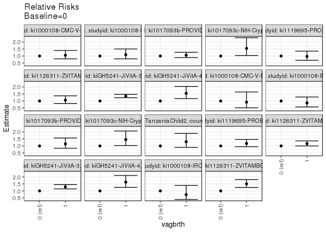

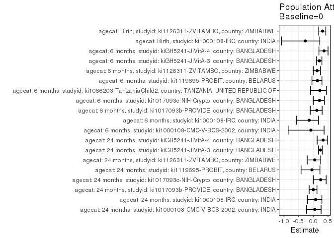

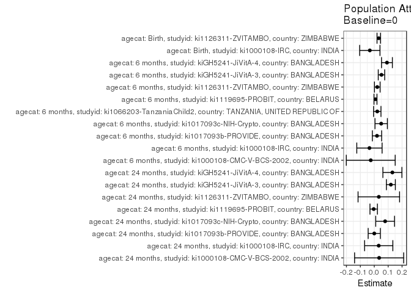

## Results Table

### Parameter: TSM

| agecat | studyid | country | intervention_level | baseline_level | estimate | ci_lower | ci_upper |
| --- | --- | --- | --- | --- | --- | --- | --- |
| Birth | ki1000108-IRC | INDIA | 0 | NA | 0.1479052 | 0.0655283 | 0.2302821 |
| Birth | ki1000108-IRC | INDIA | 1 | NA | 0.1089870 | 0.0748392 | 0.1431348 |
| Birth | ki1126311-ZVITAMBO | ZIMBABWE | 0 | NA | 0.0703541 | 0.0576473 | 0.0830609 |
| Birth | ki1126311-ZVITAMBO | ZIMBABWE | 1 | NA | 0.1055703 | 0.1002092 | 0.1109313 |
| 6 months | ki1000108-CMC-V-BCS-2002 | INDIA | 0 | NA | 0.3260304 | 0.1436800 | 0.5083808 |
| 6 months | ki1000108-CMC-V-BCS-2002 | INDIA | 1 | NA | 0.2989995 | 0.2505524 | 0.3474467 |
| 6 months | ki1000108-IRC | INDIA | 0 | NA | 0.2803086 | 0.1797037 | 0.3809134 |
| 6 months | ki1000108-IRC | INDIA | 1 | NA | 0.2403207 | 0.1948882 | 0.2857533 |
| 6 months | ki1017093b-PROVIDE | BANGLADESH | 0 | NA | 0.1416129 | 0.1048123 | 0.1784136 |
| 6 months | ki1017093b-PROVIDE | BANGLADESH | 1 | NA | 0.1623811 | 0.1304662 | 0.1942961 |
| 6 months | ki1017093c-NIH-Crypto | BANGLADESH | 0 | NA | 0.1864542 | 0.1308558 | 0.2420525 |
| 6 months | ki1017093c-NIH-Crypto | BANGLADESH | 1 | NA | 0.2716359 | 0.2196257 | 0.3236462 |
| 6 months | ki1066203-TanzaniaChild2 | TANZANIA, UNITED REPUBLIC OF | 0 | NA | 0.0765835 | 0.0494598 | 0.1037072 |
| 6 months | ki1066203-TanzaniaChild2 | TANZANIA, UNITED REPUBLIC OF | 1 | NA | 0.0996992 | 0.0860757 | 0.1133227 |
| 6 months | ki1119695-PROBIT | BELARUS | 0 | NA | 0.0538890 | 0.0377703 | 0.0700077 |
| 6 months | ki1119695-PROBIT | BELARUS | 1 | NA | 0.0633326 | 0.0495552 | 0.0771101 |
| 6 months | ki1126311-ZVITAMBO | ZIMBABWE | 0 | NA | 0.1449873 | 0.1239210 | 0.1660536 |
| 6 months | ki1126311-ZVITAMBO | ZIMBABWE | 1 | NA | 0.1694008 | 0.1609738 | 0.1778278 |
| 6 months | kiGH5241-JiVitA-3 | BANGLADESH | 0 | NA | 0.1996682 | 0.1762844 | 0.2230520 |
| 6 months | kiGH5241-JiVitA-3 | BANGLADESH | 1 | NA | 0.2578589 | 0.2495609 | 0.2661569 |
| 6 months | kiGH5241-JiVitA-4 | BANGLADESH | 0 | NA | 0.1584384 | 0.1187004 | 0.1981765 |
| 6 months | kiGH5241-JiVitA-4 | BANGLADESH | 1 | NA | 0.2574724 | 0.2405346 | 0.2744102 |
| 24 months | ki1000108-CMC-V-BCS-2002 | INDIA | 0 | NA | 0.6800000 | 0.4968984 | 0.8631016 |
| 24 months | ki1000108-CMC-V-BCS-2002 | INDIA | 1 | NA | 0.7175793 | 0.6701495 | 0.7650090 |
| 24 months | ki1000108-IRC | INDIA | 0 | NA | 0.3836099 | 0.2724447 | 0.4947751 |
| 24 months | ki1000108-IRC | INDIA | 1 | NA | 0.4201461 | 0.3676969 | 0.4725954 |
| 24 months | ki1017093b-PROVIDE | BANGLADESH | 0 | NA | 0.3292132 | 0.2824209 | 0.3760056 |
| 24 months | ki1017093b-PROVIDE | BANGLADESH | 1 | NA | 0.3487180 | 0.3071931 | 0.3902428 |
| 24 months | ki1017093c-NIH-Crypto | BANGLADESH | 0 | NA | 0.2333222 | 0.1512822 | 0.3153622 |
| 24 months | ki1017093c-NIH-Crypto | BANGLADESH | 1 | NA | 0.3603235 | 0.2868205 | 0.4338264 |
| 24 months | ki1119695-PROBIT | BELARUS | 0 | NA | 0.0893452 | 0.0529353 | 0.1257551 |
| 24 months | ki1119695-PROBIT | BELARUS | 1 | NA | 0.0866806 | 0.0573600 | 0.1160011 |
| 24 months | ki1126311-ZVITAMBO | ZIMBABWE | 0 | NA | 0.6204636 | 0.4651383 | 0.7757888 |
| 24 months | ki1126311-ZVITAMBO | ZIMBABWE | 1 | NA | 0.6555949 | 0.6103265 | 0.7008632 |
| 24 months | kiGH5241-JiVitA-3 | BANGLADESH | 0 | NA | 0.3714498 | 0.3389194 | 0.4039802 |
| 24 months | kiGH5241-JiVitA-3 | BANGLADESH | 1 | NA | 0.4995689 | 0.4862303 | 0.5129075 |
| 24 months | kiGH5241-JiVitA-4 | BANGLADESH | 0 | NA | 0.2606311 | 0.1887115 | 0.3325508 |
| 24 months | kiGH5241-JiVitA-4 | BANGLADESH | 1 | NA | 0.4023376 | 0.3832064 | 0.4214688 |

### Parameter: E(Y)

| agecat | studyid | country | intervention_level | baseline_level | estimate | ci_lower | ci_upper |
| --- | --- | --- | --- | --- | --- | --- | --- |
| Birth | ki1000108-IRC | INDIA | NA | NA | 0.1159794 | 0.0840777 | 0.1478811 |
| Birth | ki1126311-ZVITAMBO | ZIMBABWE | NA | NA | 0.1027997 | 0.0977170 | 0.1078823 |
| 6 months | ki1000108-CMC-V-BCS-2002 | INDIA | NA | NA | 0.3008130 | 0.2539566 | 0.3476694 |
| 6 months | ki1000108-IRC | INDIA | NA | NA | 0.2457002 | 0.2038248 | 0.2875757 |
| 6 months | ki1017093b-PROVIDE | BANGLADESH | NA | NA | 0.1612350 | 0.1313580 | 0.1911120 |
| 6 months | ki1017093c-NIH-Crypto | BANGLADESH | NA | NA | 0.2363239 | 0.1973320 | 0.2753157 |
| 6 months | ki1066203-TanzaniaChild2 | TANZANIA, UNITED REPUBLIC OF | NA | NA | 0.0982544 | 0.0852222 | 0.1112865 |
| 6 months | ki1119695-PROBIT | BELARUS | NA | NA | 0.0626864 | 0.0488489 | 0.0765238 |
| 6 months | ki1126311-ZVITAMBO | ZIMBABWE | NA | NA | 0.1667477 | 0.1586931 | 0.1748023 |
| 6 months | kiGH5241-JiVitA-3 | BANGLADESH | NA | NA | 0.2515539 | 0.2434271 | 0.2596807 |
| 6 months | kiGH5241-JiVitA-4 | BANGLADESH | NA | NA | 0.2497532 | 0.2336426 | 0.2658638 |
| 24 months | ki1000108-CMC-V-BCS-2002 | INDIA | NA | NA | 0.7150538 | 0.6691221 | 0.7609854 |
| 24 months | ki1000108-IRC | INDIA | NA | NA | 0.4156479 | 0.3678270 | 0.4634689 |
| 24 months | ki1017093b-PROVIDE | BANGLADESH | NA | NA | 0.3292894 | 0.2909105 | 0.3676684 |
| 24 months | ki1017093c-NIH-Crypto | BANGLADESH | NA | NA | 0.3115385 | 0.2551365 | 0.3679404 |
| 24 months | ki1119695-PROBIT | BELARUS | NA | NA | 0.0852540 | 0.0554439 | 0.1150642 |
| 24 months | ki1126311-ZVITAMBO | ZIMBABWE | NA | NA | 0.6533333 | 0.6093135 | 0.6973532 |
| 24 months | kiGH5241-JiVitA-3 | BANGLADESH | NA | NA | 0.4909133 | 0.4777756 | 0.5040511 |
| 24 months | kiGH5241-JiVitA-4 | BANGLADESH | NA | NA | 0.3910448 | 0.3723963 | 0.4096932 |

### Parameter: RR

| agecat | studyid | country | intervention_level | baseline_level | estimate | ci_lower | ci_upper |
| --- | --- | --- | --- | --- | --- | --- | --- |
| Birth | ki1000108-IRC | INDIA | 0 | 0 | 1.0000000 | 1.0000000 | 1.000000 |
| Birth | ki1000108-IRC | INDIA | 1 | 0 | 0.7368705 | 0.3893284 | 1.394653 |
| Birth | ki1126311-ZVITAMBO | ZIMBABWE | 0 | 0 | 1.0000000 | 1.0000000 | 1.000000 |
| Birth | ki1126311-ZVITAMBO | ZIMBABWE | 1 | 0 | 1.5005561 | 1.2440504 | 1.809950 |
| 6 months | ki1000108-CMC-V-BCS-2002 | INDIA | 0 | 0 | 1.0000000 | 1.0000000 | 1.000000 |
| 6 months | ki1000108-CMC-V-BCS-2002 | INDIA | 1 | 0 | 0.9170909 | 0.5124965 | 1.641096 |
| 6 months | ki1000108-IRC | INDIA | 0 | 0 | 1.0000000 | 1.0000000 | 1.000000 |
| 6 months | ki1000108-IRC | INDIA | 1 | 0 | 0.8573435 | 0.5716002 | 1.285930 |
| 6 months | ki1017093b-PROVIDE | BANGLADESH | 0 | 0 | 1.0000000 | 1.0000000 | 1.000000 |
| 6 months | ki1017093b-PROVIDE | BANGLADESH | 1 | 0 | 1.1466549 | 0.8391937 | 1.566763 |
| 6 months | ki1017093c-NIH-Crypto | BANGLADESH | 0 | 0 | 1.0000000 | 1.0000000 | 1.000000 |
| 6 months | ki1017093c-NIH-Crypto | BANGLADESH | 1 | 0 | 1.4568511 | 1.0267151 | 2.067190 |
| 6 months | ki1066203-TanzaniaChild2 | TANZANIA, UNITED REPUBLIC OF | 0 | 0 | 1.0000000 | 1.0000000 | 1.000000 |
| 6 months | ki1066203-TanzaniaChild2 | TANZANIA, UNITED REPUBLIC OF | 1 | 0 | 1.3018363 | 0.8938568 | 1.896028 |
| 6 months | ki1119695-PROBIT | BELARUS | 0 | 0 | 1.0000000 | 1.0000000 | 1.000000 |
| 6 months | ki1119695-PROBIT | BELARUS | 1 | 0 | 1.1752429 | 0.9443292 | 1.462621 |
| 6 months | ki1126311-ZVITAMBO | ZIMBABWE | 0 | 0 | 1.0000000 | 1.0000000 | 1.000000 |
| 6 months | ki1126311-ZVITAMBO | ZIMBABWE | 1 | 0 | 1.1683838 | 1.0027464 | 1.361382 |
| 6 months | kiGH5241-JiVitA-3 | BANGLADESH | 0 | 0 | 1.0000000 | 1.0000000 | 1.000000 |
| 6 months | kiGH5241-JiVitA-3 | BANGLADESH | 1 | 0 | 1.2914371 | 1.1455433 | 1.455912 |
| 6 months | kiGH5241-JiVitA-4 | BANGLADESH | 0 | 0 | 1.0000000 | 1.0000000 | 1.000000 |
| 6 months | kiGH5241-JiVitA-4 | BANGLADESH | 1 | 0 | 1.6250625 | 1.2557086 | 2.103058 |
| 24 months | ki1000108-CMC-V-BCS-2002 | INDIA | 0 | 0 | 1.0000000 | 1.0000000 | 1.000000 |
| 24 months | ki1000108-CMC-V-BCS-2002 | INDIA | 1 | 0 | 1.0552636 | 0.7997388 | 1.392431 |
| 24 months | ki1000108-IRC | INDIA | 0 | 0 | 1.0000000 | 1.0000000 | 1.000000 |
| 24 months | ki1000108-IRC | INDIA | 1 | 0 | 1.0952432 | 0.7988540 | 1.501598 |
| 24 months | ki1017093b-PROVIDE | BANGLADESH | 0 | 0 | 1.0000000 | 1.0000000 | 1.000000 |
| 24 months | ki1017093b-PROVIDE | BANGLADESH | 1 | 0 | 1.0592465 | 0.8851304 | 1.267613 |
| 24 months | ki1017093c-NIH-Crypto | BANGLADESH | 0 | 0 | 1.0000000 | 1.0000000 | 1.000000 |
| 24 months | ki1017093c-NIH-Crypto | BANGLADESH | 1 | 0 | 1.5443171 | 1.0348108 | 2.304687 |
| 24 months | ki1119695-PROBIT | BELARUS | 0 | 0 | 1.0000000 | 1.0000000 | 1.000000 |
| 24 months | ki1119695-PROBIT | BELARUS | 1 | 0 | 0.9701761 | 0.6962985 | 1.351779 |
| 24 months | ki1126311-ZVITAMBO | ZIMBABWE | 0 | 0 | 1.0000000 | 1.0000000 | 1.000000 |
| 24 months | ki1126311-ZVITAMBO | ZIMBABWE | 1 | 0 | 1.0566211 | 0.8176838 | 1.365379 |
| 24 months | kiGH5241-JiVitA-3 | BANGLADESH | 0 | 0 | 1.0000000 | 1.0000000 | 1.000000 |
| 24 months | kiGH5241-JiVitA-3 | BANGLADESH | 1 | 0 | 1.3449163 | 1.2289488 | 1.471827 |
| 24 months | kiGH5241-JiVitA-4 | BANGLADESH | 0 | 0 | 1.0000000 | 1.0000000 | 1.000000 |
| 24 months | kiGH5241-JiVitA-4 | BANGLADESH | 1 | 0 | 1.5437050 | 1.1680907 | 2.040103 |

### Parameter: PAR

| agecat | studyid | country | intervention_level | baseline_level | estimate | ci_lower | ci_upper |
| --- | --- | --- | --- | --- | --- | --- | --- |
| Birth | ki1000108-IRC | INDIA | 0 | NA | -0.0319258 | -0.1050793 | 0.0412277 |
| Birth | ki1126311-ZVITAMBO | ZIMBABWE | 0 | NA | 0.0324456 | 0.0199613 | 0.0449298 |
| 6 months | ki1000108-CMC-V-BCS-2002 | INDIA | 0 | NA | -0.0252174 | -0.2010012 | 0.1505664 |
| 6 months | ki1000108-IRC | INDIA | 0 | NA | -0.0346083 | -0.1255877 | 0.0563711 |
| 6 months | ki1017093b-PROVIDE | BANGLADESH | 0 | NA | 0.0196221 | -0.0138057 | 0.0530499 |
| 6 months | ki1017093c-NIH-Crypto | BANGLADESH | 0 | NA | 0.0498697 | 0.0052916 | 0.0944478 |
| 6 months | ki1066203-TanzaniaChild2 | TANZANIA, UNITED REPUBLIC OF | 0 | NA | 0.0216708 | -0.0049170 | 0.0482587 |
| 6 months | ki1119695-PROBIT | BELARUS | 0 | NA | 0.0087974 | -0.0019608 | 0.0195556 |
| 6 months | ki1126311-ZVITAMBO | ZIMBABWE | 0 | NA | 0.0217604 | 0.0013609 | 0.0421599 |
| 6 months | kiGH5241-JiVitA-3 | BANGLADESH | 0 | NA | 0.0518857 | 0.0287845 | 0.0749869 |
| 6 months | kiGH5241-JiVitA-4 | BANGLADESH | 0 | NA | 0.0913148 | 0.0522643 | 0.1303652 |
| 24 months | ki1000108-CMC-V-BCS-2002 | INDIA | 0 | NA | 0.0350538 | -0.1413823 | 0.2114898 |
| 24 months | ki1000108-IRC | INDIA | 0 | NA | 0.0320380 | -0.0696228 | 0.1336989 |
| 24 months | ki1017093b-PROVIDE | BANGLADESH | 0 | NA | 0.0000762 | -0.0436530 | 0.0438054 |
| 24 months | ki1017093c-NIH-Crypto | BANGLADESH | 0 | NA | 0.0782163 | 0.0106751 | 0.1457574 |
| 24 months | ki1119695-PROBIT | BELARUS | 0 | NA | -0.0040911 | -0.0308030 | 0.0226207 |
| 24 months | ki1126311-ZVITAMBO | ZIMBABWE | 0 | NA | 0.0328698 | -0.1164127 | 0.1821522 |
| 24 months | kiGH5241-JiVitA-3 | BANGLADESH | 0 | NA | 0.1194635 | 0.0871360 | 0.1517910 |
| 24 months | kiGH5241-JiVitA-4 | BANGLADESH | 0 | NA | 0.1304136 | 0.0620139 | 0.1988134 |

### Parameter: PAF

| agecat | studyid | country | intervention_level | baseline_level | estimate | ci_lower | ci_upper |
| --- | --- | --- | --- | --- | --- | --- | --- |
| Birth | ki1000108-IRC | INDIA | 0 | NA | -0.2752715 | -1.0876000 | 0.2209631 |
| Birth | ki1126311-ZVITAMBO | ZIMBABWE | 0 | NA | 0.3156193 | 0.1845170 | 0.4256448 |
| 6 months | ki1000108-CMC-V-BCS-2002 | INDIA | 0 | NA | -0.0838308 | -0.8583444 | 0.3678840 |
| 6 months | ki1000108-IRC | INDIA | 0 | NA | -0.1408558 | -0.5789804 | 0.1757010 |
| 6 months | ki1017093b-PROVIDE | BANGLADESH | 0 | NA | 0.1216986 | -0.1042254 | 0.3013987 |
| 6 months | ki1017093c-NIH-Crypto | BANGLADESH | 0 | NA | 0.2110227 | -0.0008500 | 0.3780435 |
| 6 months | ki1066203-TanzaniaChild2 | TANZANIA, UNITED REPUBLIC OF | 0 | NA | 0.2205585 | -0.0967376 | 0.4460579 |
| 6 months | ki1119695-PROBIT | BELARUS | 0 | NA | 0.1403399 | -0.0469875 | 0.2941506 |
| 6 months | ki1126311-ZVITAMBO | ZIMBABWE | 0 | NA | 0.1304991 | -0.0002269 | 0.2441397 |
| 6 months | kiGH5241-JiVitA-3 | BANGLADESH | 0 | NA | 0.2062609 | 0.1096887 | 0.2923578 |
| 6 months | kiGH5241-JiVitA-4 | BANGLADESH | 0 | NA | 0.3656200 | 0.1909727 | 0.5025656 |
| 24 months | ki1000108-CMC-V-BCS-2002 | INDIA | 0 | NA | 0.0490226 | -0.2327896 | 0.2664133 |
| 24 months | ki1000108-IRC | INDIA | 0 | NA | 0.0770798 | -0.2028716 | 0.2918764 |
| 24 months | ki1017093b-PROVIDE | BANGLADESH | 0 | NA | 0.0002314 | -0.1417798 | 0.1245797 |
| 24 months | ki1017093c-NIH-Crypto | BANGLADESH | 0 | NA | 0.2510646 | 0.0013332 | 0.4383469 |
| 24 months | ki1119695-PROBIT | BELARUS | 0 | NA | -0.0479877 | -0.4177010 | 0.2253103 |
| 24 months | ki1126311-ZVITAMBO | ZIMBABWE | 0 | NA | 0.0503109 | -0.2080141 | 0.2533949 |
| 24 months | kiGH5241-JiVitA-3 | BANGLADESH | 0 | NA | 0.2433495 | 0.1755357 | 0.3055855 |
| 24 months | kiGH5241-JiVitA-4 | BANGLADESH | 0 | NA | 0.3335005 | 0.1313687 | 0.4885960 |